# Intro & Repetition

Statistical Programming with R

## Welcome

## Provisional programme

| **Day** | **Time** | **Purpose/Details** | **Material** | **Lecturer** |
| --- | --- | --- | --- | --- |
| Tuesday | 09.00 - 10.30 | Intro & Repetition | A | Aksel |
|  | 10.30 - 12:00 | Sampling | B | Signe |
|  | 13:00 - 15:30 | Sampling *continued* | B | Signe |
|  | 13:00 - 15:30 | Estimation and calibration | C | Signe |
| Wednesday | 09:00 - 12:00 | Estimation and calibration *continued* | D | Aksel |
|  | 09:00 - 12:00 | Functional programmering | D | Aksel |
|  | 13:00 - 15:30 | Prepare and analyse large data | E | Aksel |
| Thursday | 09:00 - 12:00 | Further work with large data | F | Aksel |

## Format

- Same as the last courses
- Lectures followed by practicals
- Materials are on the [homepage](https://akselthomsen.github.io/IR-Bosnia-III/)
- Including execises, solutions and data
- Please do ask questions!

## Repitition

1. A few base R essentials
2. R Objects
3. Tidyverse
4. Importing data into R

## A few base R essentials

## Native classes

- Types:
  - `vector`
  - `matrix`
  - `list`
  - `data.frame`

## Native classes

- Classes:
  - `numeric`
  - `integer`
  - `character`
  - `logical`
  - `Date`
  - `POSIXct` or datetime
  - `factor`

## Functions for later

- `aggregate`: Summarise data
- `cut`: Divide variables

## Aggregate

- Summarise a data frame
- Formula based

```r
df <- data.frame(group = c(1,1,1,2,2), x = 1:5)
df
```

```
##   group x
## 1     1 1
## 2     1 2
## 3     1 3
## 4     2 4
## 5     2 5
```

## Aggregate

- Summarise a data frame
- Formula based

```r
aggregate(x ~ group, data = df, FUN = sum)
```

```
##   group x
## 1     1 6
## 2     2 9
```

## Cut

- Divides the range
- Recodes numeric to factor

```r
x <- runif(n = 10, min = 0, max = 1)
x
```

```
##  [1] 0.16804223 0.69922088 0.15070977 0.90499637 0.05591136 0.64259041
##  [7] 0.84122129 0.65651344 0.08180915 0.56343198
```

## Cut

- Divides the range
- Recodes numeric to factor
- Default is lower bound not included!

```r
(y <- cut(x = x, breaks = c(0,0.25,0.75,1)))
```

```
##  [1] (0,0.25]    (0.25,0.75] (0,0.25]    (0.75,1]    (0,0.25]    (0.25,0.75]
##  [7] (0.75,1]    (0.25,0.75] (0,0.25]    (0.25,0.75]
## Levels: (0,0.25] (0.25,0.75] (0.75,1]
```

```r
table(y)
```

```
## y
##    (0,0.25] (0.25,0.75]    (0.75,1]
##           4           4           2
```

## R objects

## Objects and classes

- Many more exists!
- Everyone can define a new object class
- Statistical packages and functions often have their own objects

## Example 1

- `table` object

```r
x <- sample(x = 1:2, size = 50, replace = TRUE)
table(x)
```

```
## x
##  1  2
## 25 25
```

```r
class(table(x))
```

```
## [1] "table"
```

## Example 2

- `lm` object

```r
x <- rnorm(n = 100, mean = 1, sd = 1)
y <- 2 + 3 * x + rnorm(n = 100, mean = 0, sd = 0.5)

linear_model <- lm(formula = y ~ x)
class(linear_model)
```

```
## [1] "lm"
```

```r
linear_model
```

```
##
## Call:
## lm(formula = y ~ x)
##
## Coefficients:
## (Intercept)            x
##       2.089        2.994
```

## Example 2

- Also own summary method

```r
summary(linear_model)
```

```
##
## Call:
## lm(formula = y ~ x)
##
## Residuals:
##      Min       1Q   Median       3Q      Max
## -0.74206 -0.33453 -0.08727  0.24254  1.10100
##
## Coefficients:
##             Estimate Std. Error t value Pr(>|t|)
## (Intercept)  2.08904    0.06243   33.46   <2e-16 ***
## x            2.99384    0.04141   72.30   <2e-16 ***
## ---
## Signif. codes:  0 '***' 0.001 '**' 0.01 '*' 0.05 '.' 0.1 ' ' 1
##
## Residual standard error: 0.4549 on 98 degrees of freedom
## Multiple R-squared:  0.9816, Adjusted R-squared:  0.9814
## F-statistic:  5228 on 1 and 98 DF,  p-value: < 2.2e-16
```

## Into the Tidyverse

## What is it?

- From Rstudio: [tidyverse.org](https://www.tidyverse.org/)
- Common (and opinionated) collection of packages
- Pipes
- `dplyr`
- `tibbles`
- `ggplot2`
- And more

```r
library(tidyverse)
```

## Piping

- Easier to read for humans
- Alternative to nested functions calls
- Most important one: `%>%`
- LHS is the first argument to RHS

## Piping - Example

- Bad:

```r
summarise(group_by(mtcars,am), hp = mean(hp))
```

- Good:

```r
mtcars %>%
  group_by(am) %>%
  summarise(hp = mean(hp))
```

```
## # A tibble: 2 x 2
##      am    hp
##   <dbl> <dbl>
## 1     0  160.
## 2     1  127.
```

## Dplyr verbs

- Transforming `data.frames`
- Datatransformation [Cheat Sheet](https://github.com/rstudio/cheatsheets/raw/master/data-transformation.pdf)
  - `select`
  - `filter`
  - `mutate`
  - `group_by`
  - `summarise`
- Joins
  - `left_join`
  - `right_join`
  - `full_join`

## Tibbles

- Rethinking of the base `data.frame`
- New object class
- More restrictive
- More “tidy”
- No rownames
- Much better default print method
- (why i would recommend it)
- Look into the `tidyr` package
- Check out the [Data Import Cheat Sheet](https://github.com/rstudio/cheatsheets/raw/master/data-import.pdf)

## Tibbles

- Normal `data.frame`

```r
mtcars
```

```
##                      mpg cyl  disp  hp drat    wt  qsec vs am gear carb
## Mazda RX4           21.0   6 160.0 110 3.90 2.620 16.46  0  1    4    4
## Mazda RX4 Wag       21.0   6 160.0 110 3.90 2.875 17.02  0  1    4    4
## Datsun 710          22.8   4 108.0  93 3.85 2.320 18.61  1  1    4    1
## Hornet 4 Drive      21.4   6 258.0 110 3.08 3.215 19.44  1  0    3    1
## Hornet Sportabout   18.7   8 360.0 175 3.15 3.440 17.02  0  0    3    2
## Valiant             18.1   6 225.0 105 2.76 3.460 20.22  1  0    3    1
## Duster 360          14.3   8 360.0 245 3.21 3.570 15.84  0  0    3    4
## Merc 240D           24.4   4 146.7  62 3.69 3.190 20.00  1  0    4    2
## Merc 230            22.8   4 140.8  95 3.92 3.150 22.90  1  0    4    2
## Merc 280            19.2   6 167.6 123 3.92 3.440 18.30  1  0    4    4
## Merc 280C           17.8   6 167.6 123 3.92 3.440 18.90  1  0    4    4
## Merc 450SE          16.4   8 275.8 180 3.07 4.070 17.40  0  0    3    3
## Merc 450SL          17.3   8 275.8 180 3.07 3.730 17.60  0  0    3    3
## Merc 450SLC         15.2   8 275.8 180 3.07 3.780 18.00  0  0    3    3
## Cadillac Fleetwood  10.4   8 472.0 205 2.93 5.250 17.98  0  0    3    4
## Lincoln Continental 10.4   8 460.0 215 3.00 5.424 17.82  0  0    3    4
## Chrysler Imperial   14.7   8 440.0 230 3.23 5.345 17.42  0  0    3    4
## Fiat 128            32.4   4  78.7  66 4.08 2.200 19.47  1  1    4    1
## Honda Civic         30.4   4  75.7  52 4.93 1.615 18.52  1  1    4    2
## Toyota Corolla      33.9   4  71.1  65 4.22 1.835 19.90  1  1    4    1
## Toyota Corona       21.5   4 120.1  97 3.70 2.465 20.01  1  0    3    1
## Dodge Challenger    15.5   8 318.0 150 2.76 3.520 16.87  0  0    3    2
## AMC Javelin         15.2   8 304.0 150 3.15 3.435 17.30  0  0    3    2
## Camaro Z28          13.3   8 350.0 245 3.73 3.840 15.41  0  0    3    4
## Pontiac Firebird    19.2   8 400.0 175 3.08 3.845 17.05  0  0    3    2
## Fiat X1-9           27.3   4  79.0  66 4.08 1.935 18.90  1  1    4    1
## Porsche 914-2       26.0   4 120.3  91 4.43 2.140 16.70  0  1    5    2
## Lotus Europa        30.4   4  95.1 113 3.77 1.513 16.90  1  1    5    2
## Ford Pantera L      15.8   8 351.0 264 4.22 3.170 14.50  0  1    5    4
## Ferrari Dino        19.7   6 145.0 175 3.62 2.770 15.50  0  1    5    6
## Maserati Bora       15.0   8 301.0 335 3.54 3.570 14.60  0  1    5    8
## Volvo 142E          21.4   4 121.0 109 4.11 2.780 18.60  1  1    4    2
```

## Tibbles

- When it is a `tibble`:

```r
as_tibble(mtcars)
```

```
## # A tibble: 32 x 11
##      mpg   cyl  disp    hp  drat    wt  qsec    vs    am  gear  carb
##    <dbl> <dbl> <dbl> <dbl> <dbl> <dbl> <dbl> <dbl> <dbl> <dbl> <dbl>
##  1  21       6  160    110  3.9   2.62  16.5     0     1     4     4
##  2  21       6  160    110  3.9   2.88  17.0     0     1     4     4
##  3  22.8     4  108     93  3.85  2.32  18.6     1     1     4     1
##  4  21.4     6  258    110  3.08  3.22  19.4     1     0     3     1
##  5  18.7     8  360    175  3.15  3.44  17.0     0     0     3     2
##  6  18.1     6  225    105  2.76  3.46  20.2     1     0     3     1
##  7  14.3     8  360    245  3.21  3.57  15.8     0     0     3     4
##  8  24.4     4  147.    62  3.69  3.19  20       1     0     4     2
##  9  22.8     4  141.    95  3.92  3.15  22.9     1     0     4     2
## 10  19.2     6  168.   123  3.92  3.44  18.3     1     0     4     4
## # ... with 22 more rows
```

## Tibbles

- A bit of wrangling with `tidyr`:

```r
mtcars %>%
  rownames_to_column(var = "car") %>%
  as_tibble() %>%
  print(n = 5, width = 50)
```

```
## # A tibble: 32 x 12
##   car      mpg   cyl  disp    hp  drat    wt  qsec
##   <chr>  <dbl> <dbl> <dbl> <dbl> <dbl> <dbl> <dbl>
## 1 Mazda~  21       6   160   110  3.9   2.62  16.5
## 2 Mazda~  21       6   160   110  3.9   2.88  17.0
## 3 Datsu~  22.8     4   108    93  3.85  2.32  18.6
## 4 Horne~  21.4     6   258   110  3.08  3.22  19.4
## 5 Horne~  18.7     8   360   175  3.15  3.44  17.0
## # ... with 27 more rows, and 4 more variables:
## #   vs <dbl>, am <dbl>, gear <dbl>, carb <dbl>
```

## ggplot2

- Very good graphic package
- Grammar of grapics
- RStudio again
- [Reference guide](https://ggplot2.tidyverse.org/reference/index.html)
- [Data Visualisation Cheat Sheet](https://github.com/rstudio/cheatsheets/raw/master/data-visualization-2.1.pdf)

## Example 1

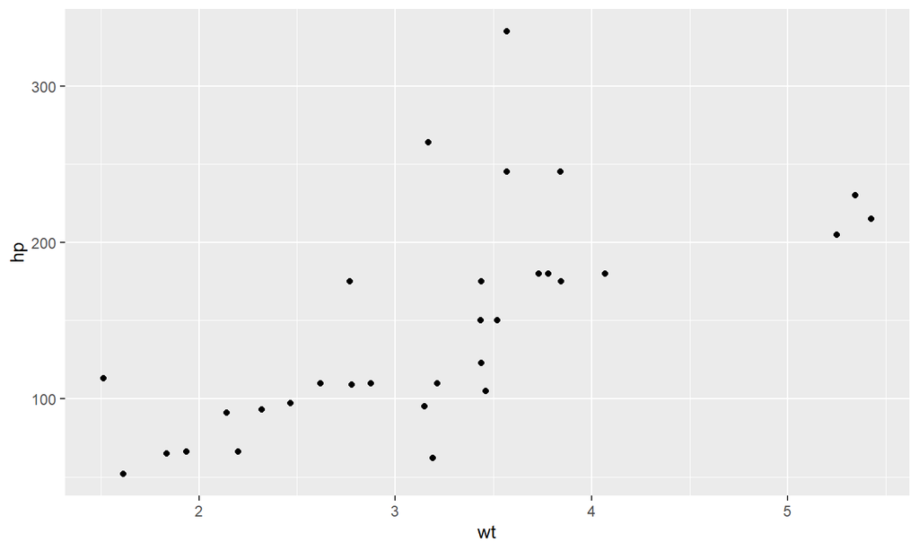

```r
ggplot(data = mtcars,
       mapping = aes(x = wt, y = hp)) +
  geom_point()
```

## Example 2

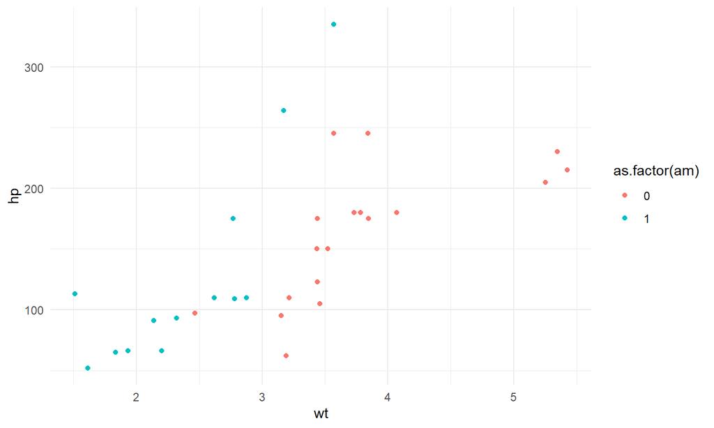

```r
ggplot(data = mtcars,
       mapping = aes(x = wt, y = hp, colour = as.factor(am))) +
  geom_point() +
  theme_minimal()
```

## Importing data into R

## Very common task

- Native object class for data is the `data.frame`
- Import/export through `.RData` or `.rds` files
- But data is almost always from somewhere else
- Most commonly: CSV & Excel files
- But also supprt for other formats: SAS, SPSS and many more

## Standard R data

```r
df1 <- mtcars

saveRDS(object =df1, file = "mtcars.rds")

df2 <- readRDS(file = "mtcars.rds")

all_equal(df1,df2)
```

```
## [1] TRUE
```

## Importing CSV

```r
df <- read.csv(file = "mtcars5.csv")
df
```

```
##                 car  mpg cyl disp  hp drat    wt  qsec vs am gear carb
## 1         Mazda RX4 21.0   6  160 110 3.90 2.620 16.46  0  1    4    4
## 2     Mazda RX4 Wag 21.0   6  160 110 3.90 2.875 17.02  0  1    4    4
## 3        Datsun 710 22.8   4  108  93 3.85 2.320 18.61  1  1    4    1
## 4    Hornet 4 Drive 21.4   6  258 110 3.08 3.215 19.44  1  0    3    1
## 5 Hornet Sportabout 18.7   8  360 175 3.15 3.440 17.02  0  0    3    2
```

## Check the output

- Is it to be expected?
- Check the column classes
- Very rarely you actually want factors!

```r
as_tibble(df)
```

```
## # A tibble: 5 x 12
##   car            mpg   cyl  disp    hp  drat    wt  qsec    vs    am  gear  carb
##   <fct>        <dbl> <int> <int> <int> <dbl> <dbl> <dbl> <int> <int> <int> <int>
## 1 Mazda RX4     21       6   160   110  3.9   2.62  16.5     0     1     4     4
## 2 Mazda RX4 W~  21       6   160   110  3.9   2.88  17.0     0     1     4     4
## 3 Datsun 710    22.8     4   108    93  3.85  2.32  18.6     1     1     4     1
## 4 Hornet 4 Dr~  21.4     6   258   110  3.08  3.22  19.4     1     0     3     1
## 5 Hornet Spor~  18.7     8   360   175  3.15  3.44  17.0     0     0     3     2
```

## Two options

1. Control with arguments to the base R function
2. Use the excellent ´readr´ package (in general a really good idea!)

## Option 1

```r
as_tibble(read.csv("mtcars5.csv", stringsAsFactors = FALSE))
```

```
## # A tibble: 5 x 12
##   car            mpg   cyl  disp    hp  drat    wt  qsec    vs    am  gear  carb
##   <chr>        <dbl> <int> <int> <int> <dbl> <dbl> <dbl> <int> <int> <int> <int>
## 1 Mazda RX4     21       6   160   110  3.9   2.62  16.5     0     1     4     4
## 2 Mazda RX4 W~  21       6   160   110  3.9   2.88  17.0     0     1     4     4
## 3 Datsun 710    22.8     4   108    93  3.85  2.32  18.6     1     1     4     1
## 4 Hornet 4 Dr~  21.4     6   258   110  3.08  3.22  19.4     1     0     3     1
## 5 Hornet Spor~  18.7     8   360   175  3.15  3.44  17.0     0     0     3     2
```

## Option 2

```r
df <- readr::read_csv("mtcars5.csv")
```

## Option 2

```r
df
```

```
## # A tibble: 5 x 12
##   car            mpg   cyl  disp    hp  drat    wt  qsec    vs    am  gear  carb
##   <chr>        <dbl> <dbl> <dbl> <dbl> <dbl> <dbl> <dbl> <dbl> <dbl> <dbl> <dbl>
## 1 Mazda RX4     21       6   160   110  3.9   2.62  16.5     0     1     4     4
## 2 Mazda RX4 W~  21       6   160   110  3.9   2.88  17.0     0     1     4     4
## 3 Datsun 710    22.8     4   108    93  3.85  2.32  18.6     1     1     4     1
## 4 Hornet 4 Dr~  21.4     6   258   110  3.08  3.22  19.4     1     0     3     1
## 5 Hornet Spor~  18.7     8   360   175  3.15  3.44  17.0     0     0     3     2
```

## For Excel

- Excellent `openxlsx` package
- Both to write and read

```r
df <- openxlsx::read.xlsx(xlsxFile = "mtcars5.xlsx")
as_tibble(df)
```

```
## # A tibble: 5 x 12
##   car            mpg   cyl  disp    hp  drat    wt  qsec    vs    am  gear  carb
##   <chr>        <dbl> <dbl> <dbl> <dbl> <dbl> <dbl> <dbl> <dbl> <dbl> <dbl> <dbl>
## 1 Mazda RX4     21       6   160   110  3.9   2.62  16.5     0     1     4     4
## 2 Mazda RX4 W~  21       6   160   110  3.9   2.88  17.0     0     1     4     4
## 3 Datsun 710    22.8     4   108    93  3.85  2.32  18.6     1     1     4     1
## 4 Hornet 4 Dr~  21.4     6   258   110  3.08  3.22  19.4     1     0     3     1
## 5 Hornet Spor~  18.7     8   360   175  3.15  3.44  17.0     0     0     3     2
```

## For everything else

- The `haven` package has all the foreign formats:
- read_dta
- read_spss
- read_xpt
- read_stata
- read_sas
- read_sav
- read_por